[figure not shown]

# **DATA 607 - Assignment 2- Week 2B Classification Metrics Code Base**

### **Bikash Bhowmik —- 12 Sep 2026**

Overview  
Calculating Null Error Rate  
Calculations for 0.2 threshold  
Confusion Matrix for 0.2 threshold  
Calculating Performance Metrics for 0.2 threshold  
Calculations for 0.5 threshold  
Creating a Confusion Matrix for 0.5 threshold  
Calculating Performance Metrics for 0.5 threshold  
Calculations for 0.8 threshold  
Creating a Confusion Matrix for 0.8 threshold  
Calculating Performance Metrics for 0.8 threshold  
Threshold Use Cases  
Conclusion

**Overview**

For this assignment, I used the given data to calculate the null error rate and created a plot to show the distribution of the actual classes. I also explained why the null error rate is important when evaluating a model.

Next, I calculated the True Positives, False Positives, True Negatives, and False Negatives using three probability thresholds: 0.2, 0.5, and 0.8. I showed the results using three confusion matrices.

Then, I calculated the accuracy, precision, recall, and F1 score for each threshold and displayed the results in a table.

Finally, I provided some real-world examples to explain when using a 0.2 threshold or a 0.8 threshold would be more useful.

Below is the data file link from github repository

https://raw.githubusercontent.com/BIKASHBHOWMIK15/Data-607/main/Assignment2/penguin_predictions.csv

In this assignment

Female = Positive  
Male = Negative

Then:

TP: Female → Female ✅  
FP: Male → Female ❌  
TN: Male → Male ✅  
FN: Female → Male ❌

**Calculating Null Error Rate**

Null Error Rate is a baseline metric that indicates how often you would be wrong if you always predicted the majority class.

```r
url <- "https://raw.githubusercontent.com/BIKASHBHOWMIK15/Data-607/main/Assignment2/penguin_predictions.csv"

df <- read_csv(
  file = url,
  show_col_types = FALSE,
  progress = FALSE
)

class_counts <- table(df$sex)

# Find the majority class count and total count
majority_count <- max(class_counts)
total_count <- sum(class_counts)

# Calculate the proportion of the majority class
majority_proportion <- majority_count / total_count

# The null error rate is 1 minus the majority proportion
null_error_rate <- 1 - majority_proportion

# Print the result
print(paste("Null Error Rate:", null_error_rate))
```

```
[1] "Null Error Rate: 0.419354838709677"
```

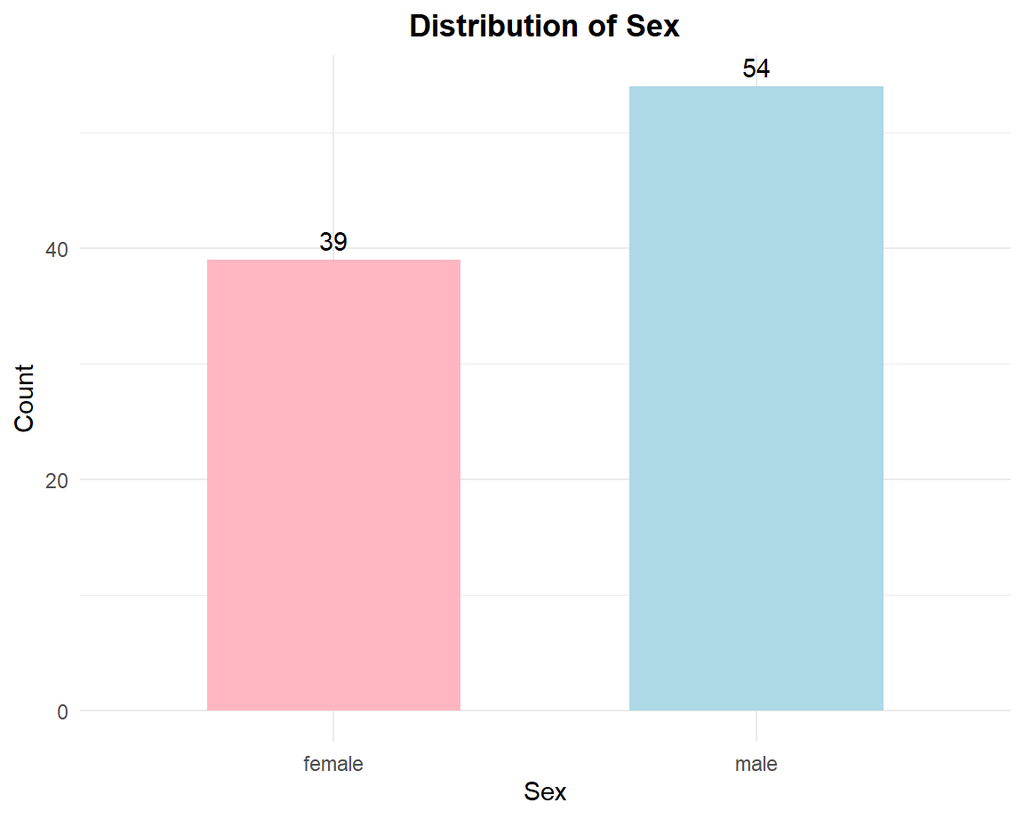

```r
ggplot(df, aes(x = sex, fill = sex)) +
  geom_bar(width = 0.6) +
  geom_text(
    stat = "count",
    aes(label = after_stat(count)),
    vjust = -0.5
  ) +
  scale_fill_manual(
    values = c(
      "male" = "lightblue",
      "female" = "lightpink"
    )
  ) +
  labs(
    title = "Distribution of Sex",
    x = "Sex",
    y = "Count"
  ) +
  theme_minimal() +
  theme(
    plot.title = element_text(face = "bold", hjust = 0.5),
    legend.position = "none"
  )
```

This plot shows the distribution of the actual sex classes in the data.

The null error rate is important because it gives us a baseline for comparing our model. It helps us see whether the model is actually learning from the data or simply predicting the majority class.

**Calculations for 0.2 threshold**

First we’ll start with calculating the True Positives, True Negatives, False Positives, and False Negatives for 0.2 threshold.

```r
# Defined threshold
threshold <- 0.2

# Function to calculate True Positives
get_true_positives <- function(p, y, t) {
  preds <- ifelse(p >= t, 1, 0)
  sum(preds == 1 & y == 1)
}

# True Positives for specified threshold
true_positives_02 <- get_true_positives(df$.pred_female, ifelse(df$sex == "female", 1, 0), threshold)

# Function to calculate True Negatives
get_true_negatives <- function(p, y, t) {
  preds <- ifelse(p >= t, 1, 0)
  sum(preds == 0 & y == 0)
}

# True Negatives for specified threshold
true_negatives_02 <- get_true_negatives(df$.pred_female, ifelse(df$sex == "female", 1, 0), threshold)

# Function to calculate False Positives
get_false_positives <- function(p, y, t) {
  preds <- ifelse(p >= t, 1, 0)
  sum(preds == 1 & y == 0)
}

# False Positives for specified threshold
false_positives_02 <- get_false_positives(df$.pred_female, ifelse(df$sex == "female", 1, 0), threshold)

# Function to calculate False Negatives
get_false_negatives <- function(p, y, t) {
  preds <- ifelse(p >= t, 1, 0)
  sum(preds == 0 & y == 1)
}

# False Negatives for specified threshold
false_negatives_02 <- get_false_negatives(df$.pred_female, ifelse(df$sex == "female", 1, 0), threshold)

# Create vectors for items and values
item_names <- c("True Positives", "True Negatives", "False Positives", "False Negatives")
item_values <- c(true_positives_02, true_negatives_02, false_positives_02, false_negatives_02)

# Combine them into a data frame
item_table <- data.frame(Item = item_names, Value = item_values)

# Display the table
print(item_table)
```

```
             Item Value
1  True Positives    37
2  True Negatives    48
3 False Positives     6
4 False Negatives     2
```

**Confusion Matrix for 0.2 threshold**

The threshold was set to 0.2, meaning that any predicted probability of being female that is greater than or equal to 0.2 is classified as female. Probabilities below 0.2 are classified as male.

The confusion matrix shows how the predicted classifications compare with the actual sex values. This helps evaluate how well the model is classifying the observations at this threshold.

Using a lower threshold of 0.2 makes the model more likely to predict female, because even a relatively small predicted probability is enough to classify an observation as female.

```r
actual_values <- ifelse(df$sex == "female", 1, 0)
predicted_probs <- df$.pred_female

# Defined threshold
threshold <- 0.2

# Convert probabilities to binary class predictions using the threshold
# Values >= threshold become 1, otherwise 0
predicted_values <- ifelse(predicted_probs >= threshold, 1, 0)

# Create the confusion table
confusion_matrix_02 <- table(predicted_values, actual_values)
print(confusion_matrix_02)
```

```
                actual_values
predicted_values  0  1
               0 48  2
               1  6 37
```

**Calculating Performance Metrics for 0.2 threshold**

Calculating the accuracy, precision, recall, f1 score for 0.2 threshold

```r
correct_predictions_02 <- (true_positives_02 + true_negatives_02)

# Total number of observations
total_observations_02 <- sum(true_positives_02 + true_negatives_02 + false_positives_02 + false_negatives_02)

# Calculate accuracy
accuracy_02 <- correct_predictions_02 / total_observations_02

# Calculate the precision
precision_02 <- true_positives_02 / (true_positives_02 + false_positives_02)

# Calculate the recall
recall_02 <- true_positives_02 / (true_positives_02 + false_negatives_02)

# Calculate the f1 score
f1_score_02 <- 2 * (precision_02 * recall_02) / (precision_02 + recall_02)

# Create vectors for performance metrics
performance_metrics_names <- c("Accuracy", "Precision", "Recall", "F1 Score")
performance_metrics_values <- c(accuracy_02, precision_02, recall_02, f1_score_02)

# Combine them into a data frame
performance_metrics_table <- data.frame("Performance Metric" = performance_metrics_names, Value = performance_metrics_values)

# Display the table
print(performance_metrics_table)
```

```
  Performance.Metric     Value
1           Accuracy 0.9139785
2          Precision 0.8604651
3             Recall 0.9487179
4           F1 Score 0.9024390
```

**Calculations for 0.5 threshold**

First we’ll start with calculating the True Positives, True Negatives, False Positives, and False Negatives for 0.5 threshold.

```r
# Defined threshold
threshold <- 0.5

# Function to calculate True Positives
get_true_positives <- function(p, y, t) {
  preds <- ifelse(p >= t, 1, 0)
  sum(preds == 1 & y == 1)
}

# True Positives for specified threshold
true_positives_05 <- get_true_positives(df$.pred_female, ifelse(df$sex == "female", 1, 0), threshold)

# Function to calculate True Negatives
get_true_negatives <- function(p, y, t) {
  preds <- ifelse(p >= t, 1, 0)
  sum(preds == 0 & y == 0)
}

# True Negatives for specified threshold
true_negatives_05 <- get_true_negatives(df$.pred_female, ifelse(df$sex == "female", 1, 0), threshold)

# Function to calculate False Positives
get_false_positives <- function(p, y, t) {
  preds <- ifelse(p >= t, 1, 0)
  sum(preds == 1 & y == 0)
}

# False Positives for specified threshold
false_positives_05 <- get_false_positives(df$.pred_female, ifelse(df$sex == "female", 1, 0), threshold)

# Function to calculate False Negatives
get_false_negatives <- function(p, y, t) {
  preds <- ifelse(p >= t, 1, 0)
  sum(preds == 0 & y == 1)
}

# False Negatives for specified threshold
false_negatives_05 <- get_false_negatives(df$.pred_female, ifelse(df$sex == "female", 1, 0), threshold)

# Create vectors for items and values
item_names <- c("True Positives", "True Negatives", "False Positives", "False Negatives")
item_values <- c(true_positives_05, true_negatives_05, false_positives_05, false_negatives_05)

# Combine them into a data frame
item_table <- data.frame(Item = item_names, Value = item_values)

# Display the table
print(item_table)
```

```
             Item Value
1  True Positives    36
2  True Negatives    51
3 False Positives     3
4 False Negatives     3
```

**Creating a Confusion Matrix for 0.5 threshold**

```r
actual_values <- ifelse(df$sex == "female", 1, 0)
predicted_probs <- df$.pred_female

# Defined threshold
threshold <- 0.5

# Convert probabilities to binary class predictions using the threshold
# Values >= threshold become 1, otherwise 0
predicted_values <- ifelse(predicted_probs >= threshold, 1, 0)

# Create the confusion table
confusion_matrix_05 <- table(predicted_values, actual_values)
print(confusion_matrix_05)
```

```
                actual_values
predicted_values  0  1
               0 51  3
               1  3 36
```

**Calculating Performance Metrics for 0.5 threshold**

Calculating the accuracy, precision, recall, f1 score for 0.5 threshold

```r
correct_predictions_05 <- (true_positives_05 + true_negatives_05)

# Total number of observations
total_observations_05 <- sum(true_positives_05 + true_negatives_05 + false_positives_05 + false_negatives_05)

# Calculate accuracy
accuracy_05 <- correct_predictions_05 / total_observations_05

# Calculate the precision
precision_05 <- true_positives_05 / (true_positives_05 + false_positives_05)

# Calculate the recall
recall_05 <- true_positives_05 / (true_positives_05 + false_negatives_05)

# Calculate the f1 score
f1_score_05 <- 2 * (precision_05 * recall_05) / (precision_05 + recall_05)

# Create vectors for performance metrics
performance_metrics_names <- c("Accuracy", "Precision", "Recall", "F1 Score")
performance_metrics_values <- c(accuracy_05, precision_05, recall_05, f1_score_05)

# Combine them into a data frame
performance_metrics_table <- data.frame("Performance Metric" = performance_metrics_names, Value = performance_metrics_values)

# Display the table
print(performance_metrics_table)
```

```
  Performance.Metric     Value
1           Accuracy 0.9354839
2          Precision 0.9230769
3             Recall 0.9230769
4           F1 Score 0.9230769
```

**Calculations for 0.8 threshold**

First we’ll start with calculating the True Positives, True Negatives, False Positives, and False Negatives for 0.8 threshold.

```r
# Defined threshold
threshold <- 0.8

# Function to calculate True Positives
get_true_positives <- function(p, y, t) {
  preds <- ifelse(p >= t, 1, 0)
  sum(preds == 1 & y == 1)
}

# True Positives for specified threshold
true_positives_08 <- get_true_positives(df$.pred_female, ifelse(df$sex == "female", 1, 0), threshold)

# Function to calculate True Negatives
get_true_negatives <- function(p, y, t) {
  preds <- ifelse(p >= t, 1, 0)
  sum(preds == 0 & y == 0)
}

# True Negatives for specified threshold
true_negatives_08 <- get_true_negatives(df$.pred_female, ifelse(df$sex == "female", 1, 0), threshold)

# Function to calculate False Positives
get_false_positives <- function(p, y, t) {
  preds <- ifelse(p >= t, 1, 0)
  sum(preds == 1 & y == 0)
}

# False Positives for specified threshold
false_positives_08 <- get_false_positives(df$.pred_female, ifelse(df$sex == "female", 1, 0), threshold)

# Function to calculate False Negatives
get_false_negatives <- function(p, y, t) {
  preds <- ifelse(p >= t, 1, 0)
  sum(preds == 0 & y == 1)
}

# False Negatives for specified threshold
false_negatives_08 <- get_false_negatives(df$.pred_female, ifelse(df$sex == "female", 1, 0), threshold)

# Create vectors for items and values
item_names <- c("True Positives", "True Negatives", "False Positives", "False Negatives")
item_values <- c(true_positives_08, true_negatives_08, false_positives_08, false_negatives_08)

# Combine them into a data frame
item_table <- data.frame(Item = item_names, Value = item_values)

# Display the table
print(item_table)
```

```
             Item Value
1  True Positives    36
2  True Negatives    52
3 False Positives     2
4 False Negatives     3
```

**Creating a Confusion Matrix for 0.8 threshold**

```r
actual_values <- ifelse(df$sex == "female", 1, 0)
predicted_probs <- df$.pred_female

# Defined threshold
threshold <- 0.8

# Convert probabilities to binary class predictions using the threshold
# Values >= threshold become 1, otherwise 0
predicted_values <- ifelse(predicted_probs >= threshold, 1, 0)

# Create the confusion table
confusion_matrix_08 <- table(predicted_values, actual_values)
print(confusion_matrix_08)
```

```
                actual_values
predicted_values  0  1
               0 52  3
               1  2 36
```

**Calculating Performance Metrics for 0.8 threshold**

```r
correct_predictions_08 <- (true_positives_08 + true_negatives_08)

# Total number of observations
total_observations_08 <- sum(true_positives_08 + true_negatives_08 + false_positives_08 + false_negatives_08)

# Calculate accuracy
accuracy_08 <- correct_predictions_08 / total_observations_08

# Calculate the precision
precision_08 <- true_positives_08 / (true_positives_08 + false_positives_08)

# Calculate the recall
recall_08 <- true_positives_08 / (true_positives_08 + false_negatives_08)

# Calculate the f1 score
f1_score_08 <- 2 * (precision_08 * recall_08) / (precision_08 + recall_08)

# Create vectors for performance metrics
performance_metrics_names <- c("Accuracy", "Precision", "Recall", "F1 Score")
performance_metrics_values <- c(accuracy_08, precision_08, recall_08, f1_score_08)

# Combine them into a data frame
performance_metrics_table <- data.frame("Performance Metric" = performance_metrics_names, Value = performance_metrics_values)

# Display the table
print(performance_metrics_table)
```

```
  Performance.Metric     Value
1           Accuracy 0.9462366
2          Precision 0.9473684
3             Recall 0.9230769
4           F1 Score 0.9350649
```

**Threshold Use Cases**

One real world scenario where a 0.2 threshold is preferable is cancer screening because missing a positive case (false negative) is much more dangerous than flagging a negative case (false positive).

One real world scenario where a 0.8 threshold is preferable is credit card fraud detection because credit card companies want to reduce how often false positives happen. Otherwise customers may not be happy with the constant declines when they try to make a purchase that are slightly unusual.

**Conclusion**

In the current assignment, different probability thresholds were used to assess the effectiveness of the predictive classification model to classify the gender of penguins. First, I calculated the null error rate, which gave me an understanding of the baseline to compare the results of the evaluation. Then, I evaluated the model at thresholds of 0.2, 0.5, and 0.8.

As one may see from the results, the change in the threshold affects the number of true positives, false positives, true negatives, and false negatives. Increasing the threshold makes the model less liberal in predicting the female class. Thus, there is a trade-off between precision and recall, and one needs to decide what is more important in the task at hand in order to choose the best threshold.

The lower the threshold (such as 0.2), the better it is to have a high number of positive cases. In contrast, the higher the threshold (such as 0.8), the less likely the appearance of false positives. Thus, this assignment made me familiar with the concepts of confusion matrix, and metrics of performance like accuracy, precision, recall, and F1 score.